# Maximum cross-correlation values

Letitia Ho

10/30/2020

## 1. Are there any channels that significantly track the stimuli?

To answer this question I ran a permutation test on the maximum cross correlation values averaged across trials for all conditions. The test was run by resampling the stimuli-eeg pairings 208 times. The average maximum cross correlation value across all participants and all condition was calculated. Some of these averages are plotted below in histograms with the observed maximum cross correlation value marked in red.

### Sample histograms of permutation test results

**Figure 1**

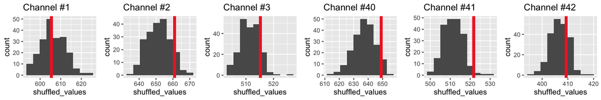

### Proportions

**Table 1**

|  | proportions |
| --- | --- |
| 1 | 0.4711538 |
| 2 | 0.0913462 |
| 3 | 0.1153846 |
| 4 | 0.1346154 |
| 5 | 0.3221154 |
| 6 | 0.4567308 |
| 7 | 0.3942308 |
| 8 | 0.3846154 |
| 9 | 0.1346154 |
| 10 | 0.3990385 |
| 11 | 0.2355769 |
| 12 | 0.3605769 |
| 13 | 0.3798077 |
| 14 | 0.3557692 |
| 15 | 0.2740385 |
| 16 | 0.3365385 |
| 17 | 0.4134615 |
| 18 | 0.1586538 |
| 19 | 0.3221154 |
| 20 | 0.3894231 |
| 21 | 0.1442308 |
| 22 | 0.1442308 |
| 23 | 0.0961538 |
| 24 | 0.1971154 |
| 25 | 0.3798077 |
| 26 | 0.1105769 |
| 27 | 0.0865385 |
| 28 | 0.0721154 |
| 29 | 0.2788462 |
| 30 | 0.2932692 |

[output cut: 98 more lines]

## 2. Is there a condition-based difference in tracking?

To answer this question I ran a permutation test results for maximum cross correlation values in each conditions. The test was run by resampling the stimuli-eeg pairings 208 times. The average maximum cross correlation value across all participants for each condition was calculated. Some of these averages are plotted below in histograms with the observed maximum cross correlation value marked in red.

### Sample histograms of permutation test results

**Figure 3: First three channels**

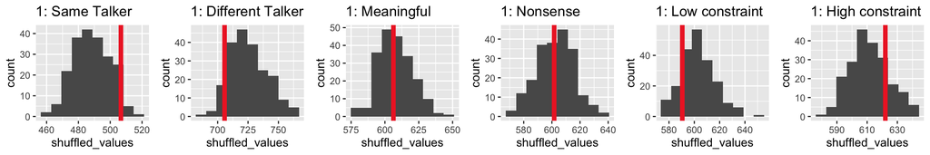

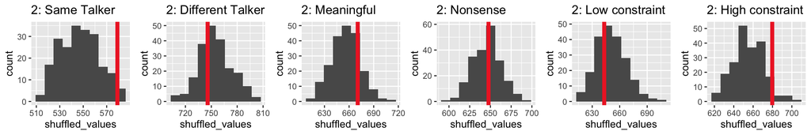

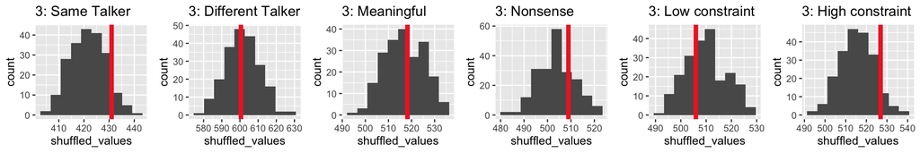

**Figure 4: Channel 30**

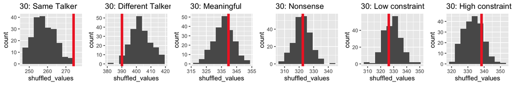

### Proportions

Proportions of resampled values that are more extreme than the observed value. Reflects the probability of obtaining the observed result based on chance.

**Table 2**

|  | same_talker | different_talker | meaningful | nonsense | low_constraint | high_constraint |
| --- | --- | --- | --- | --- | --- | --- |
| 1 | 0.0432692 | 0.0865385 | 0.4807692 | 0.4759615 | 0.1586538 | 0.2163462 |
| 2 | 0.0192308 | 0.3125 | 0.1826923 | 0.4663462 | 0.3557692 | 0.0721154 |
| 3 | 0.0817308 | 0.4711538 | 0.4423077 | 0.2451923 | 0.3269231 | 0.0721154 |
| 4 | 0.0288462 | 0.4134615 | 0.4711538 | 0.125 | 0.3894231 | 0.0480769 |
| 5 | 0.0384615 | 0.3461538 | 0.4134615 | 0.2019231 | 0.4134615 | 0.2067308 |
| 6 | 0.0048077 | 0.2067308 | 0.4567308 | 0.3173077 | 0.4711538 | 0.3557692 |
| 7 | 0.0048077 | 0.1009615 | 0.4519231 | 0.4134615 | 0.4038462 | 0.2740385 |
| 8 | 0.1826923 | 0.2259615 | 0.3990385 | 0.2836538 | 0.4038462 | 0.4711538 |
| 9 | 0.0432692 | 0.4807692 | 0.0913462 | 0.4423077 | 0.3028846 | 0.2932692 |
| 10 | 0.2644231 | 0.2836538 | 0.3942308 | 0.4951923 | 0.3605769 | 0.5048077 |
| 11 | 0.3221154 | 0.1634615 | 0.1586538 | 0.3365385 | 0.3894231 | 0.3173077 |
| 12 | 0.0432692 | 0.1105769 | 0.4663462 | 0.4951923 | 0.3653846 | 0.4663462 |
| 13 | 0 | 0.0721154 | 0.3894231 | 0.4278846 | 0.4086538 | 0.2692308 |
| 14 | 0.1634615 | 0.4519231 | 0.1298077 | 0.2259615 | 0.2163462 | 0.3557692 |
| 15 | 0.0961538 | 0.125 | 0.4711538 | 0.2403846 | 0.2355769 | 0.0528846 |
| 16 | 0.1009615 | 0.1826923 | 0.4423077 | 0.4375 | 0.3269231 | 0.1875 |
| 17 | 0.0480769 | 0.2163462 | 0.4038462 | 0.4951923 | 0.1346154 | 0.0432692 |
| 18 | 0 | 0.1298077 | 0.0480769 | 0.2788462 | 0.1586538 | 0.3701923 |
| 19 | 0.25 | 0.4134615 | 0.1826923 | 0.4278846 | 0.3365385 | 0.4807692 |
| 20 | 0.0576923 | 0.0817308 | 0.3173077 | 0.5048077 | 0.2596154 | 0.3557692 |
| 21 | 0.0192308 | 0.3461538 | 0.1105769 | 0.4326923 | 0.0288462 | 0.2596154 |
| 22 | 0 | 0.4855769 | 0.0913462 | 0.2788462 | 0.1586538 | 0.3461538 |
| 23 | 0.125 | 0.3701923 | 0.0625 | 0.4471154 | 0.2355769 | 0.2163462 |
| 24 | 0.4086538 | 0.2884615 | 0.1153846 | 0.3557692 | 0.25 | 0.4471154 |
| 25 | 0.2932692 | 0.4182692 | 0.1298077 | 0.0865385 | 0.1923077 | 0.2163462 |
| 26 | 0.0865385 | 0.4038462 | 0.0192308 | 0.2115385 | 0.1971154 | 0.3076923 |
| 27 | 0.4278846 | 0.3125 | 0.0865385 | 0.4230769 | 0.3125 | 0.2067308 |
| 28 | 0.0769231 | 0.3269231 | 0.0865385 | 0.3221154 | 0.2355769 | 0.4182692 |
| 29 | 0.0480769 | 0.125 | 0.3028846 | 0.4567308 | 0.4471154 | 0.4423077 |
| 30 | 0 | 0.0096154 | 0.2884615 | 0.4759615 | 0.3557692 | 0.2259615 |

[output cut: 98 more lines]

## 3. Which channels distinguish between levels in a condition?

**Figure 5: First three channels**

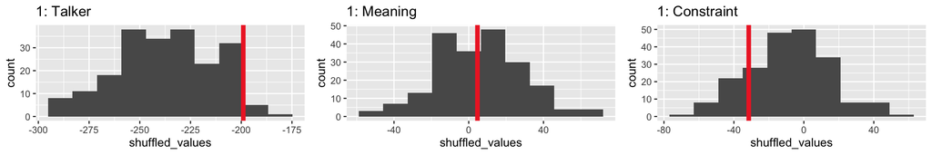

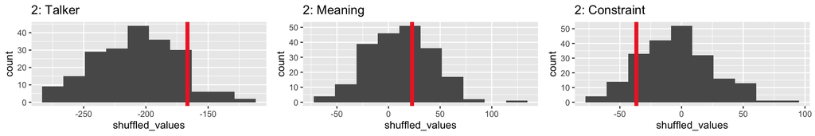

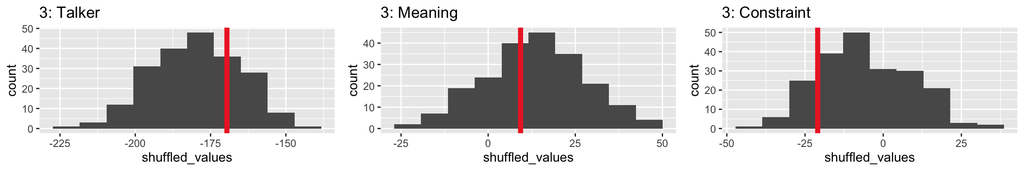

**Figure 6: Channel 30**

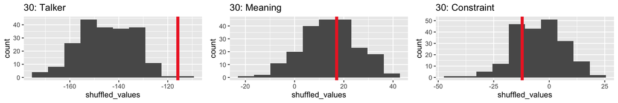

### Proportions

Proportions of differences from resampled data that are more extreme than the observed value. Reflects the probability of obtaining the observed result based on chance.

**Table 3**

|  | talker | meaning | constraint |
| --- | --- | --- | --- |
| 1 | 0.0288462 | 0.4951923 | 0.1586538 |
| 2 | 0.0961538 | 0.3221154 | 0.1538462 |
| 3 | 0.2596154 | 0.4038462 | 0.1586538 |
| 4 | 0.2163462 | 0.2596154 | 0.1346154 |
| 5 | 0.1298077 | 0.2740385 | 0.2788462 |
| 6 | 0.0480769 | 0.3317308 | 0.3798077 |
| 7 | 0.0240385 | 0.4423077 | 0.3269231 |
| 8 | 0.1826923 | 0.3173077 | 0.4951923 |
| 9 | 0.2115385 | 0.2019231 | 0.4855769 |
| 10 | 0.2307692 | 0.4615385 | 0.4615385 |
| 11 | 0.1538462 | 0.1778846 | 0.4326923 |
| 12 | 0.0480769 | 0.4951923 | 0.3798077 |
| 13 | 0 | 0.4519231 | 0.3413462 |
| 14 | 0.3990385 | 0.1057692 | 0.2403846 |
| 15 | 0.0769231 | 0.3221154 | 0.0769231 |
| 16 | 0.1201923 | 0.4855769 | 0.2019231 |
| 17 | 0.1153846 | 0.4375 | 0.0432692 |
| 18 | 0.0048077 | 0.0576923 | 0.3798077 |
| 19 | 0.3557692 | 0.2355769 | 0.4182692 |
| 20 | 0.0384615 | 0.3990385 | 0.2644231 |
| 21 | 0.3365385 | 0.25 | 0.0384615 |
| 22 | 0.1634615 | 0.0865385 | 0.3509615 |
| 23 | 0.3461538 | 0.1201923 | 0.4711538 |
| 24 | 0.3461538 | 0.2019231 | 0.3990385 |
| 25 | 0.5192308 | 0.0913462 | 0.1394231 |
| 26 | 0.1826923 | 0.0480769 | 0.4423077 |
| 27 | 0.4711538 | 0.1778846 | 0.4278846 |
| 28 | 0.1538462 | 0.1634615 | 0.3798077 |
| 29 | 0.0625 | 0.3846154 | 0.5096154 |
| 30 | 0.0048077 | 0.4134615 | 0.2644231 |

[output cut: 98 more lines]